# Video Game Recommendation System

### Video Game Recommendation System

### Datasets we have:

### User Dataset (steam-200k.csv)

### Link: https://www.kaggle.com/tamber/steam-video-games

#### Description: This dataset contains 4 attributes related to the user. The features are user_id, game_title, behavior & value.The original dataset doesn’t doesn’t have headers. It contains a total of 200,000 rows, including 5,155 unique games and 12,393 unique users.

### Importing the “steam-200k.csv” Dataset.

```r
user=read.csv(file="Datasets/steam-200k.csv")
```

### Understanding the “steam-200k.csv” data

### View the user dataset

```r
View(user)
```

### Find out the dimension of user dataset

```r
dim(user)
```

```
## [1] 199999      5
```

### Total number of rows in user dataset

```r
nrow(user)
```

```
## [1] 199999
```

### Total number of columns in user dataset

```r
ncol(user)
```

```
## [1] 5
```

### Attributes of the user dataset

```r
colnames(user)
```

```
## [1] "X151603712"                 "The.Elder.Scrolls.V.Skyrim"
## [3] "purchase"                   "X1.0"
## [5] "X0"
```

### Structure of the user dataset

```r
str(user)
```

```
## 'data.frame':    199999 obs. of  5 variables:
##  $ X151603712                : int  151603712 151603712 151603712 151603712 151603712 151603712 151603712 151603712 151603712 151603712 ...
##  $ The.Elder.Scrolls.V.Skyrim: chr  "The Elder Scrolls V Skyrim" "Fallout 4" "Fallout 4" "Spore" ...
##  $ purchase                  : chr  "play" "purchase" "play" "purchase" ...
##  $ X1.0                      : num  273 1 87 1 14.9 1 12.1 1 8.9 1 ...
##  $ X0                        : int  0 0 0 0 0 0 0 0 0 0 ...
```

### Class of the user dataframe

```r
class(user)
```

```
## [1] "data.frame"
```

### Type of user as a dataframe

```r
typeof(user)
```

```
## [1] "list"
```

### First 6 records of user

```r
head(user)
```

```
##   X151603712 The.Elder.Scrolls.V.Skyrim purchase  X1.0 X0
## 1  151603712 The Elder Scrolls V Skyrim     play 273.0  0
## 2  151603712                  Fallout 4 purchase   1.0  0
## 3  151603712                  Fallout 4     play  87.0  0
## 4  151603712                      Spore purchase   1.0  0
## 5  151603712                      Spore     play  14.9  0
## 6  151603712          Fallout New Vegas purchase   1.0  0
```

### Last 6 records of user

```r
tail(user)
```

```
##        X151603712 The.Elder.Scrolls.V.Skyrim purchase X1.0 X0
## 199994  128470551                Titan Souls purchase  1.0  0
## 199995  128470551                Titan Souls     play  1.5  0
## 199996  128470551 Grand Theft Auto Vice City purchase  1.0  0
## 199997  128470551 Grand Theft Auto Vice City     play  1.5  0
## 199998  128470551                       RUSH purchase  1.0  0
## 199999  128470551                       RUSH     play  1.4  0
```

### Checking for the occurence of NA values in user

```r
any(is.na(user))
```

```
## [1] FALSE
```

*** INFERENCE *** There are no NA values in user dataset.

### Importing the “steam_games.csv” Dataset.

```r
game=read.csv("Datasets/steam_games.csv")
```

### Understanding the “steam_games.csv” data

### View the games dataset

```r
View(game)
```

### Find out the dimensions of the game dataset

```r
dim(game)
```

```
## [1] 40833    20
```

### Total number of rows in the games dataset

```r
nrow(game)
```

```
## [1] 40833
```

### Total number of columns in the games dataset

```r
ncol(game)
```

```
## [1] 20
```

### Attributes of the games dataset

```r
colnames(game)
```

```
##  [1] "url"                      "types"
##  [3] "name"                     "desc_snippet"
##  [5] "recent_reviews"           "all_reviews"
##  [7] "release_date"             "developer"
##  [9] "publisher"                "popular_tags"
## [11] "game_details"             "languages"
## [13] "achievements"             "genre"
## [15] "game_description"         "mature_content"
## [17] "minimum_requirements"     "recommended_requirements"
## [19] "original_price"           "discount_price"
```

### Structure of the games dataset

```r
str(game)
```

```
## 'data.frame':    40833 obs. of  20 variables:
##  $ url                     : chr  "https://store.steampowered.com/app/379720/DOOM/" "https://store.steampowered.com/app/578080/PLAYERUNKNOWNS_BATTLEGROUNDS/" "https://store.steampowered.com/app/637090/BATTLETECH/" "https://store.steampowered.com/app/221100/DayZ/" ...
##  $ types                   : chr  "app" "app" "app" "app" ...
##  $ name                    : chr  "DOOM" "PLAYERUNKNOWN'S BATTLEGROUNDS" "BATTLETECH" "DayZ" ...
##  $ desc_snippet            : chr  "Now includes all three premium DLC packs (Unto the Evil, Hell Followed, and Bloodfall), maps, modes, and weapon"| __truncated__ "PLAYERUNKNOWN'S BATTLEGROUNDS is a battle royale shooter that pits 100 players against each other in a struggle"| __truncated__ "Take…
##  $ recent_reviews          : chr  "Very Positive,(554),- 89% of the 554 user reviews in the last 30 days are positive." "Mixed,(6,214),- 49% of the 6,214 user reviews in the last 30 days are positive." "Mixed,(166),- 54% of the 166 user reviews in the last 30 days are positive." "Mixed,(932),- 57…
##  $ all_reviews             : chr  "Very Positive,(42,550),- 92% of the 42,550 user reviews for this game are positive." "Mixed,(836,608),- 49% of the 836,608 user reviews for this game are positive." "Mostly Positive,(7,030),- 71% of the 7,030 user reviews for this game are positive." "Mixed,(167…
##  $ release_date            : chr  "May 12, 2016" "Dec 21, 2017" "Apr 24, 2018" "Dec 13, 2018" ...
##  $ developer               : chr  "id Software" "PUBG Corporation" "Harebrained Schemes" "Bohemia Interactive" ...
##  $ publisher               : chr  "Bethesda Softworks,Bethesda Softworks" "PUBG Corporation,PUBG Corporation" "Paradox Interactive,Paradox Interactive" "Bohemia Interactive,Bohemia Interactive" ...
##  $ popular_tags            : chr  "FPS,Gore,Action,Demons,Shooter,First-Person,Great Soundtrack,Multiplayer,Singleplayer,Fast-Paced,Sci-fi,Horror,"| __truncated__ "Survival,Shooter,Multiplayer,Battle Royale,PvP,FPS,Third-Person Shooter,Action,Online Co-Op,Tactical,Co-op,Firs"| __truncated__ "Mech…
##  $ game_details            : chr  "Single-player,Multi-player,Co-op,Steam Achievements,Steam Trading Cards,Partial Controller Support,Steam Cloud" "Multi-player,Online Multi-Player,Stats" "Single-player,Multi-player,Online Multi-Player,Cross-Platform Multiplayer,Steam Achievements,Steam Trading C…
##  $ languages               : chr  "English,French,Italian,German,Spanish - Spain,Japanese,Polish,Portuguese - Brazil,Russian,Traditional Chinese" "English,Korean,Simplified Chinese,French,German,Spanish - Spain,Arabic,Japanese,Polish,Portuguese,Russian,Turki"| __truncated__ "English,French,German…
##  $ achievements            : num  54 37 128 NaN NaN NaN 51 55 34 43 ...
##  $ genre                   : chr  "Action" "Action,Adventure,Massively Multiplayer" "Action,Adventure,Strategy" "Action,Adventure,Massively Multiplayer" ...
##  $ game_description        : chr  " About This Game Developed by id software, the studio that pioneered the first-person shooter genre and created"| __truncated__ " About This Game  PLAYERUNKNOWN'S BATTLEGROUNDS is a battle royale shooter that pits 100 players against each o"| __truncated__ " Abo…
##  $ mature_content          : chr  "" " Mature Content Description  The developers describe the content like this:  This Game may contain content not "| __truncated__ "" "" ...
##  $ minimum_requirements    : chr  "Minimum:,OS:,Windows 7/8.1/10 (64-bit versions),Processor:,Intel Core i5-2400/AMD FX-8320 or better,Memory:,8 G"| __truncated__ "Minimum:,Requires a 64-bit processor and operating system,OS:,64-bit Windows 7, Windows 8.1, Windows 10,Process"| __truncated__ "Mini…
##  $ recommended_requirements: chr  "Recommended:,OS:,Windows 7/8.1/10 (64-bit versions),Processor:,Intel Core i7-3770/AMD FX-8350 or better,Memory:"| __truncated__ "Recommended:,Requires a 64-bit processor and operating system,OS:,64-bit Windows 7, Windows 8.1, Windows 10,Pro"| __truncated__ "Reco…
##  $ original_price          : chr  "$19.99" "$29.99" "$39.99" "$44.99" ...
##  $ discount_price          : chr  "$14.99" "" "" "" ...
```

### Class of the game dataframe

```r
class(game)
```

```
## [1] "data.frame"
```

### Type of game as a dataframe

```r
typeof(game)
```

```
## [1] "list"
```

### First 6 records present in the game dataset

```r
head(game)
```

```
##                                                                                     url
## 1                                       https://store.steampowered.com/app/379720/DOOM/
## 2               https://store.steampowered.com/app/578080/PLAYERUNKNOWNS_BATTLEGROUNDS/
## 3                                 https://store.steampowered.com/app/637090/BATTLETECH/
## 4                                       https://store.steampowered.com/app/221100/DayZ/
## 5                                   https://store.steampowered.com/app/8500/EVE_Online/
## 6 https://store.steampowered.com/bundle/5699/Grand_Theft_Auto_V_Premium_Online_Edition/
##    types                                       name
## 1    app                                       DOOM
## 2    app              PLAYERUNKNOWN'S BATTLEGROUNDS
## 3    app                                 BATTLETECH
## 4    app                                       DayZ
## 5    app                                 EVE Online
## 6 bundle Grand Theft Auto V: Premium Online Edition
##                                                                                                                                                                                                                                                                                                          …
```

[output cut: 90 more lines]

### Last 6 records present in the game dataset

```r
tail(game)
```

```
##                                                                                                                                          url
## 40828                                 https://store.steampowered.com/app/899835/Rocksmith_2014_Edition__Remastered__Sabaton__Primo_Victoria/
## 40829                                 https://store.steampowered.com/app/899836/Rocksmith_2014_Edition__Remastered__Sabaton__Ghost_Division/
## 40830 https://store.steampowered.com/app/899832/Rocksmith_2014_Edition__Remastered__Stone_Temple_Pilots__Trippin_on_a_Hole_in_a_Paper_Heart/
## 40831                            https://store.steampowered.com/app/906840/Fantasy_Grounds__Quests_of_Doom_4_A_Midnight_Council_of_Quail_5E/
## 40832                                                                https://store.steampowered.com/app/906635/Mega_Man_X5_Sound_Collection/
## 40833                                                                            https://store.steampowered.com/app/908000/Stories_In_Stone/
##       types
## 40828   app
## 40829   app
## 40830   app
## 40831   app
## 40832   app
## 40833   app
##                                                                                                                name
```

[output cut: 90 more lines]

### Checking for the presence of NA values in the game dataset

```r
any(is.na(game))
```

```
## [1] TRUE
```

** INFERENCE ** There are NA values present in the game dataset.

### Dealing with the game dataset

### Print the features of the game dataset

```r
colnames(game)
```

```
##  [1] "url"                      "types"
##  [3] "name"                     "desc_snippet"
##  [5] "recent_reviews"           "all_reviews"
##  [7] "release_date"             "developer"
##  [9] "publisher"                "popular_tags"
## [11] "game_details"             "languages"
## [13] "achievements"             "genre"
## [15] "game_description"         "mature_content"
## [17] "minimum_requirements"     "recommended_requirements"
## [19] "original_price"           "discount_price"
```

### checking which columns have how many NA values

```r
sprintf("Total NA values in 'url' column = %d",sum(is.na(game$url)))
```

```
## [1] "Total NA values in 'url' column = 0"
```

```r
sprintf("Total NA values in 'types' column = %d",sum(is.na(game$types)))
```

```
## [1] "Total NA values in 'types' column = 0"
```

```r
sprintf("Total NA values in 'name' column = %d",sum(is.na(game$name)))
```

```
## [1] "Total NA values in 'name' column = 0"
```

```r
sprintf("Total NA values in 'desc_snippet' column = %d",sum(is.na(game$desc_snippet)))
```

```
## [1] "Total NA values in 'desc_snippet' column = 0"
```

```r
sprintf("Total NA values in 'recent_reviews' column = %d",sum(is.na(game$recent_reviews)))
```

```
## [1] "Total NA values in 'recent_reviews' column = 0"
```

```r
sprintf("Total NA values in 'all_reviews' column = %d",sum(is.na(game$all_reviews)))
```

```
## [1] "Total NA values in 'all_reviews' column = 0"
```

```r
sprintf("Total NA values in 'release_date' column = %d",sum(is.na(game$release_date)))
```

```
## [1] "Total NA values in 'release_date' column = 0"
```

```r
sprintf("Total NA values in 'developer' column = %d",sum(is.na(game$developer)))
```

```
## [1] "Total NA values in 'developer' column = 0"
```

```r
sprintf("Total NA values in 'publisher' column = %d",sum(is.na(game$publisher)))
```

```
## [1] "Total NA values in 'publisher' column = 0"
```

```r
sprintf("Total NA values in 'popular_tags' column = %d",sum(is.na(game$popular_tags)))
```

```
## [1] "Total NA values in 'popular_tags' column = 0"
```

```r
sprintf("Total NA values in 'game_details' column = %d",sum(is.na(game$game_details)))
```

```
## [1] "Total NA values in 'game_details' column = 0"
```

```r
sprintf("Total NA values in 'languages' column = %d",sum(is.na(game$languages)))
```

```
## [1] "Total NA values in 'languages' column = 0"
```

```r
sprintf("Total NA values in 'achievements' column = %d",sum(is.na(game$achievements)))
```

```
## [1] "Total NA values in 'achievements' column = 28639"
```

```r
sprintf("Total NA values in 'genre' column = %d",sum(is.na(game$genre)))
```

```
## [1] "Total NA values in 'genre' column = 0"
```

```r
sprintf("Total NA values in 'game_description' column = %d",sum(is.na(game$game_description)))
```

```
## [1] "Total NA values in 'game_description' column = 0"
```

```r
sprintf("Total NA values in 'mature_content' column = %d",sum(is.na(game$mature_content)))
```

```
## [1] "Total NA values in 'mature_content' column = 0"
```

```r
sprintf("Total NA values in 'minimum_requirements' column = %d",sum(is.na(game$minimum_requirements)))
```

```
## [1] "Total NA values in 'minimum_requirements' column = 0"
```

```r
sprintf("Total NA values in 'recommended_requirements' column = %d",sum(is.na(game$recommended_requirements)))
```

```
## [1] "Total NA values in 'recommended_requirements' column = 0"
```

```r
sprintf("Total NA values in 'original_price' column = %d",sum(is.na(game$original_price)))
```

```
## [1] "Total NA values in 'original_price' column = 0"
```

```r
sprintf("Total NA values in 'discount_price' column = %d",sum(is.na(game$discount_price)))
```

```
## [1] "Total NA values in 'discount_price' column = 0"
```

*** INFERENCE *** All the NA values are located in the ‘achievements’ column.

### Ambiguity in the no. of NaN values in achievements

```r
sprintf("Count of NaN values in 'achievements' using grepl(): %d",sum(grepl("NaN",game$achievements)))
```

```
## [1] "Count of NaN values in 'achievements' using grepl(): 28637"
```

```r
sprintf("Count of NaN values in 'achievements' using is.na(): %d",sum(is.na(game$achievements)))
```

```
## [1] "Count of NaN values in 'achievements' using is.na(): 28639"
```

### Sum of NaN values in columns other than achievements

```r
sprintf("Total NaN values in 'url' column = %d",sum(grepl("NaN",(game$url))))
```

```
## [1] "Total NaN values in 'url' column = 0"
```

```r
sprintf("Total NaN values in 'types' column = %d",sum(grepl("NaN",(game$types))))
```

```
## [1] "Total NaN values in 'types' column = 0"
```

```r
sprintf("Total NaN values in 'name' column = %d",sum(grepl("NaN",(game$name))))
```

```
## [1] "Total NaN values in 'name' column = 13"
```

```r
sprintf("Total NaN values in 'desc_snippet' column = %d",sum(grepl("NaN",(game$desc_snippet))))
```

```
## [1] "Total NaN values in 'desc_snippet' column = 13180"
```

```r
sprintf("Total NaN values in 'recent_reviews' column = %d",sum(grepl("NaN",(game$recent_reviews))))
```

```
## [1] "Total NaN values in 'recent_reviews' column = 2810"
```

```r
sprintf("Total NaN values in 'all_reviews' column = %d",sum(grepl("NaN",(game$all_reviews))))
```

```
## [1] "Total NaN values in 'all_reviews' column = 2810"
```

```r
sprintf("Total NaN values in 'release_date' column = %d",sum(grepl("NaN",(game$release_date))))
```

```
## [1] "Total NaN values in 'release_date' column = 3176"
```

```r
sprintf("Total NaN values in 'developer' column = %d",sum(grepl("NaN",(game$developer))))
```

```
## [1] "Total NaN values in 'developer' column = 0"
```

```r
sprintf("Total NaN values in 'publisher' column = %d",sum(grepl("NaN",(game$publisher))))
```

```
## [1] "Total NaN values in 'publisher' column = 0"
```

```r
sprintf("Total NaN values in 'popular_tags' column = %d",sum(grepl("NaN",(game$popular_tags))))
```

```
## [1] "Total NaN values in 'popular_tags' column = 2810"
```

```r
sprintf("Total NaN values in 'game_details' column = %d",sum(grepl("NaN",(game$game_details))))
```

```
## [1] "Total NaN values in 'game_details' column = 0"
```

```r
sprintf("Total NaN values in 'languages' column = %d",sum(grepl("NaN",(game$languages))))
```

```
## [1] "Total NaN values in 'languages' column = 0"
```

```r
sprintf("Total NaN values in 'genre' column = %d",sum(grepl("NaN",(game$genre))))
```

```
## [1] "Total NaN values in 'genre' column = 0"
```

```r
sprintf("Total NaN values in 'game_description' column = %d",sum(grepl("NaN",(game$game_description))))
```

```
## [1] "Total NaN values in 'game_description' column = 2815"
```

```r
sprintf("Total NaN values in 'mature_content' column = %d",sum(grepl("NaN",(game$mature_content))))
```

```
## [1] "Total NaN values in 'mature_content' column = 2810"
```

```r
sprintf("Total NaN values in 'minimum_requirements' column = %d",sum(grepl("NaN",(game$minimum_requirements))))
```

```
## [1] "Total NaN values in 'minimum_requirements' column = 2810"
```

```r
sprintf("Total NaN values in 'recommended_requirements' column = %d",sum(grepl("NaN",(game$recommended_requirements))))
```

```
## [1] "Total NaN values in 'recommended_requirements' column = 2810"
```

```r
sprintf("Total NaN values in 'original_price' column = %d",sum(grepl("NaN",(game$original_price))))
```

```
## [1] "Total NaN values in 'original_price' column = 0"
```

```r
sprintf("Total NaN values in 'discount_price' column = %d",sum(grepl("NaN",(game$discount_price))))
```

```
## [1] "Total NaN values in 'discount_price' column = 0"
```

*** INFERENCE *** The ‘NaN’ values in the above columns were present in string format. So, we were not able to detect them using is.na() function.

### Replace all the ‘NaN’ values in ‘name’, ‘desc_snippet’, ‘recent_reviews’, ‘all_reviews’, ‘release_date’, ‘popular_tags’, ‘game_description’, ‘mature_content’, ‘minimum_requirements’ and ‘recommended_requirements’ with "".

```r
game$name[grepl("NaN",game$name)] <- ""
game$desc_snippet[grepl("NaN",game$desc_snippet)] <- ""
game$recent_reviews[grepl("NaN",game$recent_reviews)] <- ""
game$all_reviews[grepl("NaN",game$all_reviews)] <- ""
game$release_date[grepl("NaN",game$release_date)] <- ""
game$popular_tags[grepl("NaN",game$popular_tags)] <- ""
game$game_description[grepl("NaN",game$game_description)] <- ""
game$mature_content[grepl("NaN",game$mature_content)] <- ""
game$minimum_requirements[grepl("NaN",game$minimum_requirements)] <- ""
game$recommended_requirements[grepl("NaN",game$recommended_requirements)] <- ""
```

*** INFERENCE *** Now the game dataset columns other than achievements are cleaned of ‘NaN’ values.

### Replace all the Na values in ‘achievements’ with 0

```r
game$achievements[is.na(game$achievements)] <- 0
```

### View the game dataset bereft of any Na/NaN values

```r
View(game)
```

### The no. of Na/NaN values in the game dataset now

```r
sum(is.na(game))
```

```
## [1] 0
```

*** INFERENCE *** The game dataset is now fully cleansed of Na/NaN values

### Using the ‘stringr’ library

```r
suppressMessages(library(stringr))
```

### Using the ‘dplyr’ library

```r
suppressMessages(library(dplyr))
```

### Removing the ‘$’ from the values of ‘original_price’ column

```r
game$original_price <- str_replace_all(game$original_price, "\\$", "")
```

### Replacing all the non-numeric characters with 0

```r
game$original_price <- gsub("^\\D.*", 0, game$original_price)
game$original_price <- sub("", 0, game$original_price)
```

All the ambiguous values are replaced with 0 in ‘original_price’ column.

### Removing the ‘$’ from the values of ‘discount_price’ column

```r
game$discount_price <- str_replace_all(game$discount_price, "\\$", "")
```

### Replacing all the "" with 0 in ‘discount_price’ column

```r
game$discount_price <- sub("", 0, game$discount_price)
```

All the ambiguous values are replaced with 0 in ‘discount_price’ column.

### Writing the cleansed dataset into a .csv file

```r
write.csv(game,"Datasets/clean_game.csv",row.names=TRUE)
```

The name of the cleansed dataset is ‘clean_game’. The user dataset is already clean, so no need to clean it.

### Reading the game dataset

```r
df = read.csv(file="Datasets/clean_game.csv")
```

### Preprocessing the all reviews column

```r
suppressMessages(library(micropan))
df1 <- df[-which(df$all_reviews == ""), ]

n = count(df1)

review = c()
for(i in (1:28470)) {
  str=df$all_reviews[i]
  str2=unlist(gregexpr(pattern='-',str))
  vex=substr(str,str2+2,str2+3)
  review <- append(review,strtoi(vex))
}

review <- data.frame(review)
review <- review[-which(is.na(review$review)), ]
```

### Distribution of Game Reviews

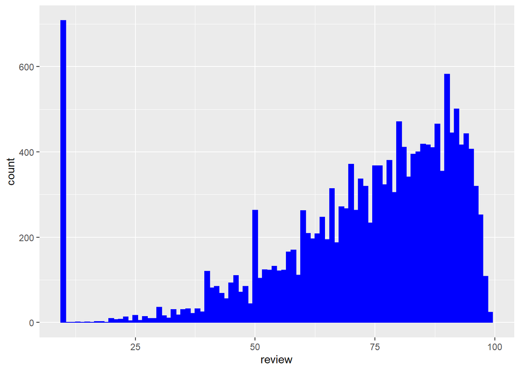

```r
suppressMessages(library(ggplot2))

ggplot() + aes(review)+ geom_histogram(binwidth=1, colour="blue", fill="blue")
```

### Preprocessing of genre column

```r
df2 <- df[-which(df$genre == ""), ]

n = count(df2)

genre1 <- df2$genre

suppressMessages(library(base))

list1 <- unlist(strsplit(genre1[1], ","))
genres = c()

for(i in (2:40395)) {
  list2 <- unlist(strsplit(genre1[i], ","))
  genres = union(list1,list2)
  list1 = genres
}

no_of_games = replicate(34,0)

genre2 <- data.frame(genres,no_of_games)
```

```r
suppressMessages(library(stringr))

for(i in (1:40395)) {
  list_store <- unlist(strsplit(genre1[i], ","))
  for(j in (1:34)) {
    if(sum(str_detect(list_store,genres[j])) == 1) {
      genre2$no_of_games[j] = genre2$no_of_games[j]+1
    }
  }
}
```

### All distinct genres

```r
genres
```

```
##  [1] "Action"                "Adventure"             "Massively Multiplayer"
##  [4] "Strategy"              "Free to Play"          "RPG"
##  [7] "Indie"                 "Early Access"          "Simulation"
## [10] "Racing"                "Casual"                "Sports"
## [13] "Violent"               "Gore"                  "Valve"
## [16] "Nudity"                "Animation & Modeling"  "Design & Illustration"
## [19] "Utilities"             "Sexual Content"        "Game Development"
## [22] "Education"             "Software Training"     "Web Publishing"
## [25] "Video Production"      "Audio Production"      "Movie"
## [28] "Photo Editing"         "Accounting"            "Documentary"
## [31] "Short"                 "360 Video"             "Tutorial"
## [34] "HTC"
```

### Plotting recurrence of genre bar chart

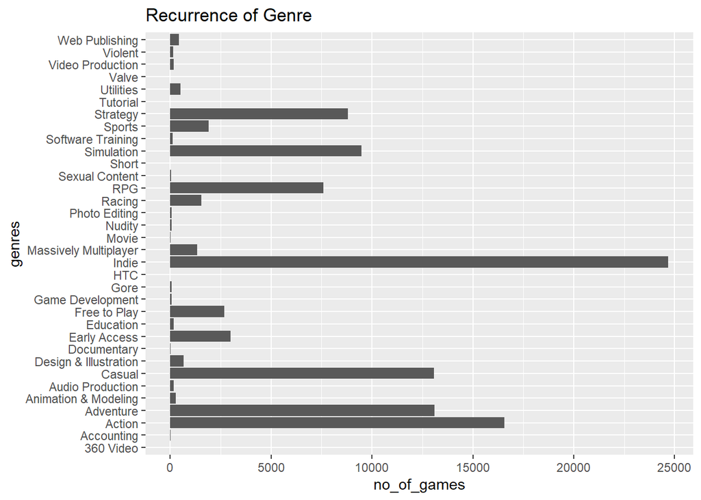

```r
ggplot(data=genre2, aes(x=no_of_games, y=genres)) + geom_bar(stat="identity") + ggtitle("Recurrence of Genre")
```

### Preprocessing popular tags column

```r
df3 <- df[-which(df$popular_tags == ""), ]

n = count(df3)

tags1 <- df3$popular_tags

suppressMessages(library(base))

list1 <- unlist(strsplit(tags1[1], ","))
popular_tags = c()

for(i in (2:37888)) {
  list2 <- unlist(strsplit(tags1[i], ","))
  popular_tags = union(list1,list2)
  list1 = popular_tags
}

no_of_games = replicate(376,0)

tags2 <- data.frame(popular_tags,no_of_games)
```

### Distinct Popular tags

```r
popular_tags
```

```
##   [1] "FPS"                               "Gore"
##   [3] "Action"                            "Demons"
##   [5] "Shooter"                           "First-Person"
##   [7] "Great Soundtrack"                  "Multiplayer"
##   [9] "Singleplayer"                      "Fast-Paced"
##  [11] "Sci-fi"                            "Horror"
##  [13] "Classic"                           "Atmospheric"
##  [15] "Difficult"                         "Blood"
##  [17] "Remake"                            "Zombies"
##  [19] "Co-op"                             "Memes"
##  [21] "Survival"                          "Battle Royale"
##  [23] "PvP"                               "Third-Person Shooter"
##  [25] "Online Co-Op"                      "Tactical"
##  [27] "Early Access"                      "Strategy"
##  [29] "Competitive"                       "Third Person"
```

[output cut: 173 more lines]

```r
suppressMessages(library(stringr))

for(i in (1:37888)) {
  list_store <- unlist(strsplit(tags1[i], ","))
  for(j in (1:376)) {
    if(sum(str_detect(list_store,popular_tags[j])) == 1) {
      tags2$no_of_games[j] = tags2$no_of_games[j]+1
    }
  }
}
```

### Plotting recurrence of popular tags bar chart

```r
arrange(tags2,desc(no_of_games))
```

```
##                          popular_tags no_of_games
## 1                               Indie       23718
## 2                              Action       15422
## 3                           Adventure       12985
## 4                              Casual       12969
## 5                          Simulation        9273
## 6                            Strategy        7890
## 7                        Singleplayer        6772
## 8                                 RPG        5649
## 9                         Multiplayer        3443
## 10                   Great Soundtrack        3209
## 11                         Soundtrack        3194
## 12                        Atmospheric        3135
## 13                                 2D        3080
## 14                       Free to Play        2886
```

[output cut: 362 more lines]

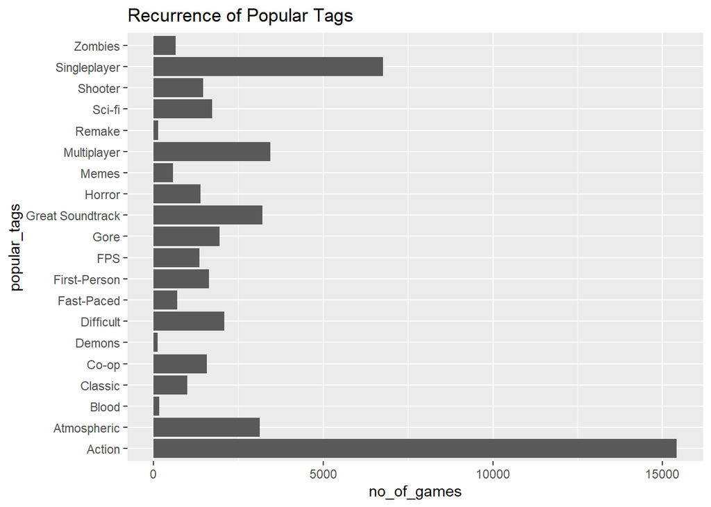

```r
tags3 = head(tags2,20)

ggplot(data=tags3, aes(x=no_of_games, y=popular_tags)) + geom_bar(stat="identity") + ggtitle("Recurrence of Popular Tags")
```

### Preprocessing game details column

```r
df4 <- df[-which(df$game_details == ""), ]

n = count(df4)

details1 <- df4$game_details

suppressMessages(library(base))

list1 <- unlist(strsplit(details1[1], ","))
game_details = c()

for(i in (2:40313)) {
  list2 <- unlist(strsplit(details1[i], ","))
  game_details = union(list1,list2)
  list1 = game_details
}

no_of_games = replicate(34,0)

details2 <- data.frame(game_details,no_of_games)
```

### Distinct game details

```r
game_details
```

```
##  [1] "Single-player"
##  [2] "Multi-player"
##  [3] "Co-op"
##  [4] "Steam Achievements"
##  [5] "Steam Trading Cards"
##  [6] "Partial Controller Support"
##  [7] "Steam Cloud"
##  [8] "Online Multi-Player"
##  [9] "Stats"
## [10] "Cross-Platform Multiplayer"
## [11] "Steam Workshop"
## [12] "Valve Anti-Cheat enabled"
## [13] "MMO"
## [14] "Online Co-op"
## [15] "Downloadable Content"
```

[output cut: 19 more lines]

```r
suppressMessages(library(stringr))

for(i in (1:40313)) {
  list_store <- unlist(strsplit(details1[i], ","))
  for(j in (1:34)) {
    if(sum(str_detect(list_store,game_details[j])) == 1) {
      details2$no_of_games[j] = details2$no_of_games[j]+1
    }
  }
}
```

### Plotting recurrence of game details bar chart

```r
arrange(details2,desc(no_of_games))
```

```
##                                                      game_details no_of_games
## 1                                                   Single-player       36463
## 2                                              Steam Achievements       22045
## 3                                            Downloadable Content       14815
## 4                                             Steam Trading Cards       13219
## 5                                                     Steam Cloud       13155
## 6                                         Full controller support       10012
## 7                                                    Multi-player        9096
## 8                           Profile Features LimitedÂ \n\t\t\t\t\t\t\t\t\t        8443
## 9                                      Partial Controller Support        7748
## 10                                             Steam Leaderboards        6801
## 11                                            Online Multi-Player        4522
## 12                                            Shared/Split Screen        4360
## 13                                                          Co-op        4247
## 14                                                          Stats        2953
```

[output cut: 20 more lines]

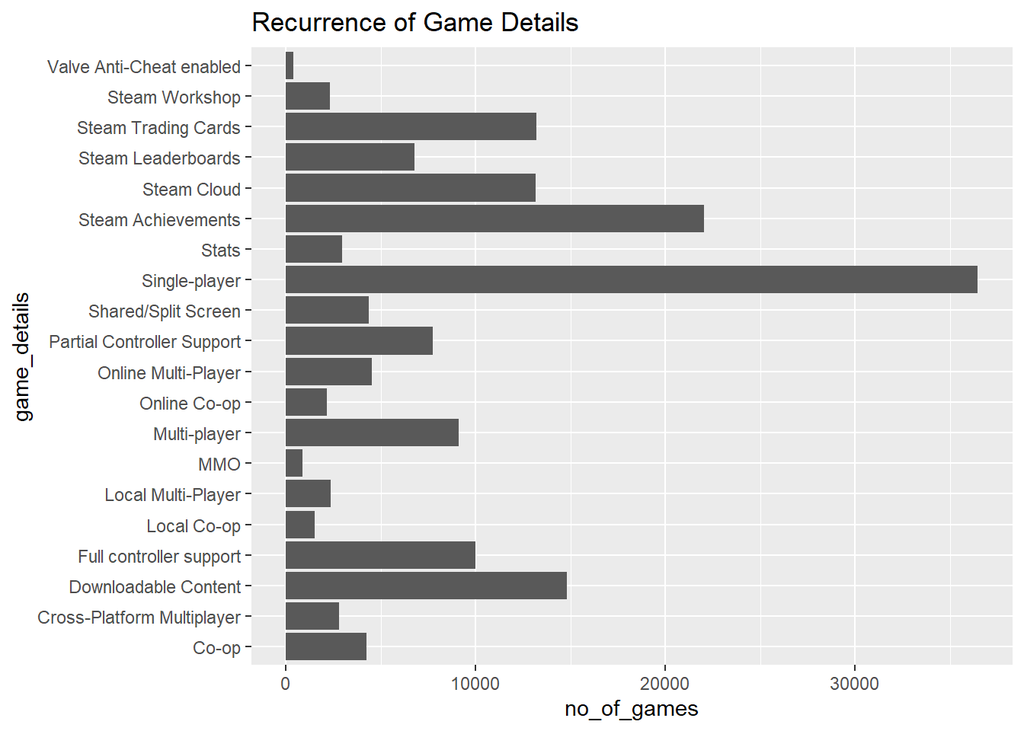

```r
details3 = head(details2,20)

ggplot(data=details3, aes(x=no_of_games, y=game_details)) + geom_bar(stat="identity") + ggtitle("Recurrence of Game Details")
```

### Including required packages

```r
suppressMessages(library(dplyr))
suppressMessages(library(ggplot2))
suppressMessages(library(mixtools))
suppressMessages(library(caTools))
suppressMessages(library(recommenderlab))
suppressMessages(library(reshape2))
steam <- read.csv('Datasets/steam-200k.csv', header = FALSE)[-5]
```

```r
head(steam)
```

```
##          V1                         V2       V3    V4
## 1 151603712 The Elder Scrolls V Skyrim purchase   1.0
## 2 151603712 The Elder Scrolls V Skyrim     play 273.0
## 3 151603712                  Fallout 4 purchase   1.0
## 4 151603712                  Fallout 4     play  87.0
## 5 151603712                      Spore purchase   1.0
## 6 151603712                      Spore     play  14.9
```

### We give user specific column names to the dataset

```r
colnames(steam) <- c('user', 'game', 'purchase_play', 'hrs')
str(steam)
```

```
## 'data.frame':    200000 obs. of  4 variables:
##  $ user         : int  151603712 151603712 151603712 151603712 151603712 151603712 151603712 151603712 151603712 151603712 ...
##  $ game         : chr  "The Elder Scrolls V Skyrim" "The Elder Scrolls V Skyrim" "Fallout 4" "Fallout 4" ...
##  $ purchase_play: chr  "purchase" "play" "purchase" "play" ...
##  $ hrs          : num  1 273 1 87 1 14.9 1 12.1 1 8.9 ...
```

```r
steam_clean <- steam
```

```r
head(steam)
```

```
##        user                       game purchase_play   hrs
## 1 151603712 The Elder Scrolls V Skyrim      purchase   1.0
## 2 151603712 The Elder Scrolls V Skyrim          play 273.0
## 3 151603712                  Fallout 4      purchase   1.0
## 4 151603712                  Fallout 4          play  87.0
## 5 151603712                      Spore      purchase   1.0
## 6 151603712                      Spore          play  14.9
```

### Check for any missing values

```r
sum(is.na(steam))
```

```
## [1] 0
```

```r
apply(steam_clean, 2, function(x) sum(is.na(x)))
```

```
##          user          game purchase_play           hrs
##             0             0             0             0
```

There are no missing values. Also, hrs column, which means hours played is already in numeric, it is crucial for our recommend-er system.

### Unless game is purchased, it can’t be played.

### We are splitting out the purchase_play column into two columns. The data collection essentially duplicates each record with one labelled as ‘purchase’ and one labelled as ‘play’. The ‘purchase’ row records 1 hour.

```r
# split into purchase and play
steam_clean$purchase <- sapply(steam_clean$purchase_play, function(x) as.numeric(x == 'purchase'))
steam_clean$play <- sapply(steam_clean$purchase_play, function(x) as.numeric(x == 'play'))
steam_clean$hrs <- steam_clean$hrs-steam_clean$purchase
steam_clean <- steam_clean[,-3] # Keep hrs, purchase and play column.
steam_clean <- aggregate(. ~ user + game, data = steam_clean, FUN = 'sum') # add user and game
head(steam_clean)
```

```
##       user                                                       game hrs
## 1 46055854                                                007 Legends 0.7
## 2 11940338                                                  0RBITALIS 0.6
## 3 86055705                                                  0RBITALIS 0.3
## 4 93030550                                                  0RBITALIS 0.3
## 5 11794760 1... 2... 3... KICK IT! (Drop That Beat Like an Ugly Baby) 0.0
## 6 35701646 1... 2... 3... KICK IT! (Drop That Beat Like an Ugly Baby) 0.0
##   purchase play
## 1        1    1
## 2        1    1
## 3        1    1
## 4        1    1
## 5        1    0
## 6        1    0
```

Here, sapply() is used to apply the function(x) to every value of purchase_play column. Aggregate() Function using formula. 1st numerical then categorical.

Each row in the reformatted dataset represents then a unique interaction user-game.

### Exploratory Data Analysis

```r
# number of games
ngames <- length(unique(steam_clean$game))

# number of users
nusers <- length(unique(steam_clean$user))

cat("There are", ngames, "games purchased by", nusers, "users")
```

```
## There are 5155 games purchased by 12393 users
```

### Top 20 games with the most users and hours played.

```r
# most played game
game_total_hrs <- aggregate(hrs ~ game, data = steam_clean, FUN = 'sum')
game_total_hrs <- game_total_hrs[order(game_total_hrs$hrs, decreasing = TRUE),]
most_played_games <- head(game_total_hrs, 20)
most_played_games <- data.frame(game = most_played_games$game, hrs = most_played_games$hrs)
df=head(most_played_games, 20)
df
```

```
##                                           game      hrs
## 1                                       Dota 2 981684.6
## 2              Counter-Strike Global Offensive 322771.6
## 3                              Team Fortress 2 173673.3
## 4                               Counter-Strike 134261.1
## 5                   Sid Meier's Civilization V  99821.3
## 6                        Counter-Strike Source  96075.5
## 7                   The Elder Scrolls V Skyrim  70889.3
## 8                                  Garry's Mod  49725.3
## 9  Call of Duty Modern Warfare 2 - Multiplayer  42009.9
## 10                               Left 4 Dead 2  33596.7
## 11                       Football Manager 2013  32308.6
## 12                       Football Manager 2012  30845.8
## 13                       Football Manager 2014  30574.8
## 14                                    Terraria  29951.8
## 15                                    Warframe  27074.6
## 16                       Football Manager 2015  24283.1
## 17                                      Arma 3  24055.7
## 18                          Grand Theft Auto V  22956.7
## 19                               Borderlands 2  22667.9
## 20                            Empire Total War  21030.3
```

### Plot of number of hours played for top 20 games.

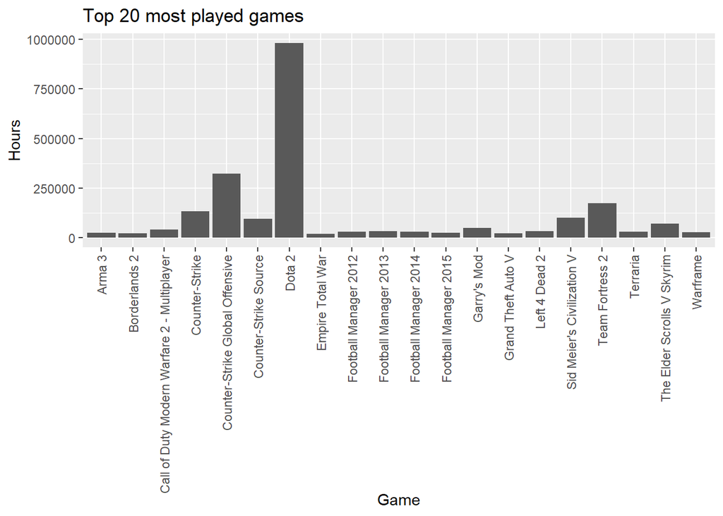

```r
ggplot(df, aes(x = game, y = hrs)) +
    geom_bar(stat = "identity") +
    theme(axis.text.x=element_text(angle=90,hjust=1,vjust=0.5)) +
    labs(title = "Top 20 most played games ", x = "Game", y = "Hours")
```

### We try to assess if the most purchased games correspond to the most played games.

```r
# game with the highest number of users
game_freq <- data.frame(sort(table(steam_clean$game), decreasing = TRUE))
colnames(game_freq) <- c("game", "nusers")
top20 <- merge(game_freq, game_total_hrs, by = 'game')
top20 <- head(top20[order(top20$nusers, decreasing = TRUE),], 20)
top20
```

```
##                                              game nusers      hrs
## 1333                                       Dota 2   4841 981684.6
## 4256                              Team Fortress 2   2323 173673.3
## 4822                                     Unturned   1563  16096.4
## 971               Counter-Strike Global Offensive   1412 322771.6
## 2075                       Half-Life 2 Lost Coast    981    184.4
## 974                         Counter-Strike Source    978  96075.5
## 2475                                Left 4 Dead 2    951  33596.7
## 968                                Counter-Strike    856 134261.1
## 4922                                     Warframe    847  27074.6
## 2072                       Half-Life 2 Deathmatch    823   3712.9
## 1888                                  Garry's Mod    731  49725.3
## 4368                   The Elder Scrolls V Skyrim    717  70889.3
## 3554                                    Robocraft    689   9096.6
## 969                 Counter-Strike Condition Zero    679   7950.0
## 970  Counter-Strike Condition Zero Deleted Scenes    679    418.2
## 2145                            Heroes & Generals    658   3299.5
## 2071                                  Half-Life 2    639   4260.3
## 3833                   Sid Meier's Civilization V    596  99821.3
## 4917                                  War Thunder    590  14381.6
## 3239                                       Portal    588   2282.8
```

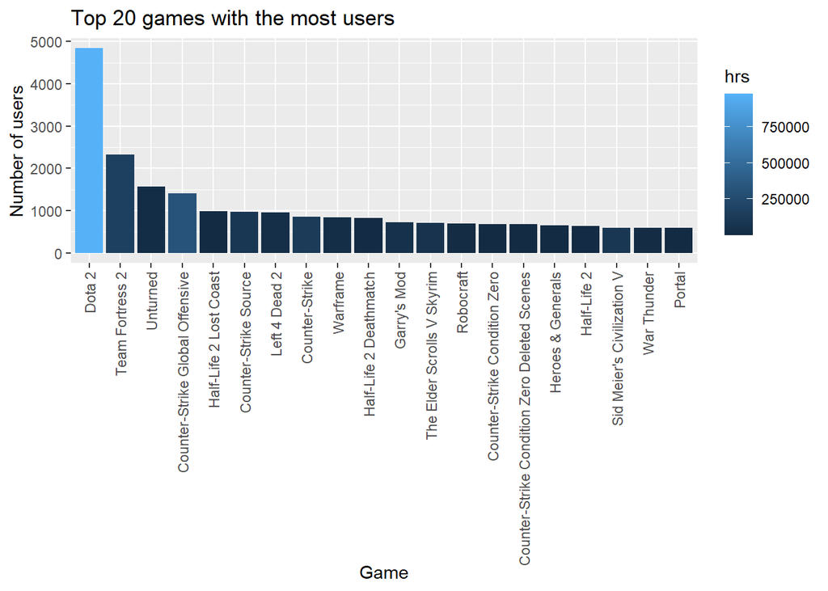

```r
ggplot(top20, aes(x = game, y = nusers, fill = hrs)) +
    geom_bar(stat = "identity") +
    theme(axis.text.x=element_text(angle=90,hjust=1,vjust=0.5)) +
    labs(title = "Top 20 games with the most users", x = "Game", y = "Number of users")
```

*** INFERENCE *** Clearly Dota 2 has the highest number of players and the highest number of total hours played so undeniably the most popular game. Where as other games such as Ricochet have 524 users but a grand total of 21.2 hours played. an interesting example is ‘Half-Life 2 Lost Coast’ which has a high number of users (981 users), but the total of hours played is quite low (184.4 hours). A possible explanation for this could be that this game was purchased as part of a game bundle.

We can clearly see that for some cases there is no relation between the total number of users and the total of hours played, meaning that a high number of users does not represent an equivalent high total of hours played.

```r
head(game_freq)
```

```
##                              game nusers
## 1                          Dota 2   4841
## 2                 Team Fortress 2   2323
## 3                        Unturned   1563
## 4 Counter-Strike Global Offensive   1412
## 5          Half-Life 2 Lost Coast    981
## 6           Counter-Strike Source    978
```

```r
# how many purchased but did not play
purchased_not_played <- subset(steam_clean, purchase == 1 & play == 0)
nTransactions <-nrow(purchased_not_played)
nusers <- length(unique(purchased_not_played$user))
nPurchased <- nrow(subset(steam_clean, purchase == 1))
cat("There are", nTransactions, "games purchased out of", nPurchased, "that have not been played by", nusers, "users")
```

```
## There are 57904 games purchased out of 128097 that have not been played by 5949 users
```

### Lot of games haven’t been played.

```r
rest = subset(steam_clean, play == 1)


game_total_hrs1 <- aggregate(hrs ~ game, data = rest, FUN = 'sum')
game_total_hrs1 <- game_total_hrs1[order(game_total_hrs1$hrs, decreasing = TRUE),]
most_played_games1 <- head(game_total_hrs1, 20)
most_played_games1 <- data.frame(game = most_played_games1$game, hrs = most_played_games1$hrs)
head(most_played_games1, 20)
```

```
##                                           game      hrs
## 1                                       Dota 2 981684.6
## 2              Counter-Strike Global Offensive 322771.6
## 3                              Team Fortress 2 173673.3
## 4                               Counter-Strike 134261.1
## 5                   Sid Meier's Civilization V  99821.3
## 6                        Counter-Strike Source  96075.5
## 7                   The Elder Scrolls V Skyrim  70889.3
## 8                                  Garry's Mod  49725.3
## 9  Call of Duty Modern Warfare 2 - Multiplayer  42009.9
## 10                               Left 4 Dead 2  33596.7
## 11                       Football Manager 2013  32308.6
## 12                       Football Manager 2012  30845.8
## 13                       Football Manager 2014  30574.8
## 14                                    Terraria  29951.8
## 15                                    Warframe  27074.6
## 16                       Football Manager 2015  24283.1
## 17                                      Arma 3  24055.7
## 18                          Grand Theft Auto V  22956.7
## 19                               Borderlands 2  22667.9
## 20                            Empire Total War  21030.3
```

*** INFERENCE ***

It seems reasonable to turn the distribution of hours played for a game into a rating, at least it’s a reasonable way to view the reception of the game. For example a bad game will have a large distribution around the 0-1 hours and a game which was well received will have a distribution of something greater.

We are going to use the EM algorithm to highlight 5 groups which can be considered 1-5 star ratings. Of course this might not be true, for example a user may only play the game for an average number of hours, but love it and would rate it a 5. The EM algorithm will be more appropriate than simply breaking the data into percentiles.

### Removing space in between values of games column

```r
# cleaning up the game columns.
steam_clean$game1 <- gsub("[^a-zA-Z0-9]", "", steam_clean$game)
head(steam_clean)
```

```
##       user                                                       game hrs
## 1 46055854                                                007 Legends 0.7
## 2 11940338                                                  0RBITALIS 0.6
## 3 86055705                                                  0RBITALIS 0.3
## 4 93030550                                                  0RBITALIS 0.3
## 5 11794760 1... 2... 3... KICK IT! (Drop That Beat Like an Ugly Baby) 0.0
## 6 35701646 1... 2... 3... KICK IT! (Drop That Beat Like an Ugly Baby) 0.0
##   purchase play                               game1
## 1        1    1                          007Legends
## 2        1    1                           0RBITALIS
## 3        1    1                           0RBITALIS
## 4        1    1                           0RBITALIS
## 5        1    0 123KICKITDropThatBeatLikeanUglyBaby
## 6        1    0 123KICKITDropThatBeatLikeanUglyBaby
```

### We create the rating system based on the distribution of hours played, this for each game available in the user dataset. We use 5 groups (equivalent to a 5 stars rating system) in order to define a rating users would give to a game they played based on the hours each one played each game relative to that of everyone else.

```
## WARNING! NOT CONVERGENT!
## number of iterations= 1000
##  lambda:  0.1230849 0.03666187 0.7280675 0.1009728 0.01121301
##  mean  :  1.584672 2.585482 3.984382 4.339596 6.204506
##  sigma :  0.5259713 0.1290138 0.7639542 0.227915 0.2375482
```

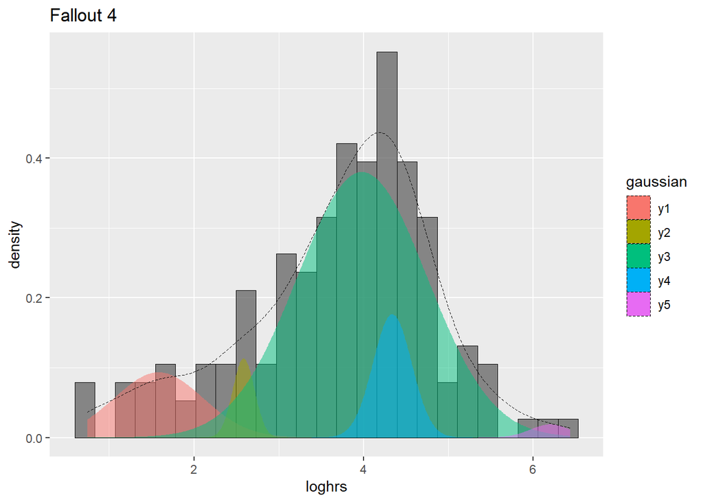

```r
# create a rating based on time played
game_hrs_density <- function(GAME, nclass, print_vals = TRUE){
  # subsetting data. Ignore the game hrs less than 2 hrs
  game_data <- subset(steam_clean, game1 == GAME & hrs > 2)
  game_data$loghrs <- log(game_data$hrs)

  # em algorithm
  mu.init <- seq(min(game_data$loghrs), max(game_data$loghrs), length = nclass)
  EM <- normalmixEM(game_data$loghrs, mu = mu.init, sigma=rep(1, nclass))

  # print results
  if(print_vals){
    cat(" lambda: ", EM$lambda, "\n mean  : ", EM$mu, "\n sigma : ", EM$sigma, "\n")
  }
  # building data frame for plotting
  x <- seq(min(game_data$loghrs), max(game_data$loghrs), 0.01)
  dens <- data.frame(x = x)
  for(k in 1:nclass){
    dens[,paste0('y', k)] <- EM$lambda[k]*dnorm(x, EM$mu[k], EM$sigma[k])
  }

  dens <- melt(dens, 'x', variable.name = 'gaussian')
  game_plt <- ggplot(game_data, aes(x = loghrs)) +
    geom_histogram(aes(y = ..density..), bins = 25, colour = "black", alpha = 0.7, size = 0.1) +
    geom_area(data = dens, aes(x = x, y = value, fill = gaussian), alpha = 0.5, position = position_dodge()) +
    geom_density(linetype = 2, size = 0.1) +
    ggtitle(game_data$game[1])

  return(game_plt)
}
game_hrs_density("Fallout4", 5, print_vals = TRUE)
```

*** INFERENCE *** EM algorithm find groups (5) of people with similar gaming habits and that would potentially rate a game in a similar way.

We can see few users played ‘The Fallout 4’ game for very few hours. It’s possible some of these users lost their interest into the game shortly after starting playing it. The distribution is denser for groups 3 and 4. This shows that the majority of users are interested in this game. So the game like this would be highly rated.

The distribution is denser for some groups . This shows that the majority of users are interested in this game.

A user-item matrix is created with the users being the rows and games being the columns. The missing values are set to zero. The observed values are the log hours for each observed user-game combination. The data was subset to games which have greater than 50 users and users which played the game for greater than 2 hours. This was chosen as 2 hours is the limit in which Steam will offer a return if we did not like the purchased game.

To create a test set 10% of the observed values will be set to 0. The root mean squared error will be calculated to determine the accuracy.

```r
# create user item matrix
set.seed(0910)
game_freq$game1 <- gsub("[^a-zA-Z0-9]", "", game_freq$game)
game_users <- subset(game_freq, game_freq$nusers > 50)
steam_clean_pos <- subset(steam_clean, steam_clean$hrs > 2 & (steam_clean$game1 %in% game_users$game1))
steam_clean_pos$loghrs <- log(steam_clean_pos$hrs)

# make matrix
games <- data.frame(game1 = sort(unique(steam_clean_pos$game1)), game_id = 1:length(unique(steam_clean_pos$game1)))
users <- data.frame(user = sort(unique(steam_clean_pos$user)), user_id = 1:length(unique(steam_clean_pos$user)))
steam_clean_pos <- merge(steam_clean_pos, games, by = 'game1')
steam_clean_pos <- merge(steam_clean_pos, users, by = 'user')
ui_mat <- matrix(0, nrow = nrow(users), ncol = nrow(games), dimnames = list(user = paste0("u", sort(unique(steam_clean_pos$user))),
                                                                            game = sort(unique(steam_clean_pos$game1))))
for(k in 1:nrow(steam_clean_pos)){
  ui_mat[steam_clean_pos$user_id[k], steam_clean_pos$game_id[k]] <- steam_clean_pos$loghrs[k]
}

# create training set i.e. suppress a tenth of the actual ratings
index <- sample.split(steam_clean_pos$user, SplitRatio = 0.9)
train <- steam_clean_pos[index,]
test <- steam_clean_pos[!index,]
ui_train <- ui_mat
for(k in 1:nrow(test)){
  ui_train[test$user_id[k], test$game_id[k]] <- 0
}

# root mean squared error function
rmse <- function(pred, test, data_frame = FALSE){
  test_pred <- rep(NA, nrow(test))
  for(k in 1:nrow(test)){
    test_pred[k] <- pred[test$user_id[k], test$game_id[k]]
  }
  if(data_frame){
    return(data.frame(test_pred, test$loghrs))
  }
  return(sqrt(1/(nrow(test)-1)*sum((test_pred - test$loghrs)^2)))
}

cat("Dimensions of training user-item matrix:", dim(ui_train))
```

```
## Dimensions of training user-item matrix: 8214 498
```

## Basic SVD recommender

The basic SVD approach will perform matrix factorisation using the first 60 leading components(iterations). Since the missing values are set to 0 the factorisation will try and recreate them which is not quite what we want. For this example we will simply impute the missing observations with a mean value. Leading COMPONENTS means Latent factors.

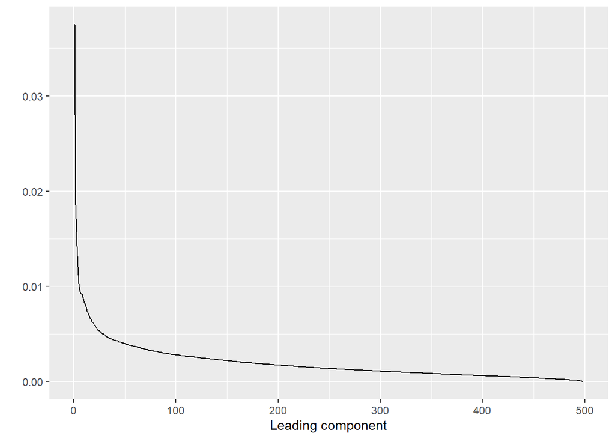

```r
Y <- ui_train

# mean impute
Y <- apply(Y, 2, function(x) ifelse(x == 0, mean(x), x))
Y_svd <- svd(Y)
U <- Y_svd$u
V <- Y_svd$v
D <- Y_svd$d
ggplot(data.frame(x = 1:length(D), y = D/sum(D)), aes(x = x, y = y)) +
    geom_line() +
    labs(x = "Leading component", y = "")
```

```r
# take the leading components
lc <- 60
pred <- U[,1:lc] %*% diag(D[1:lc]) %*% t(V[,1:lc])

rmse(pred, test)
```

```
## [1] 2.93323
```

```r
head(rmse(pred, test, TRUE))
```

```
##     test_pred test.loghrs
## 1 0.195877492    3.178054
## 2 0.263111494    2.797281
## 3 0.006601961    1.131402
## 4 0.665513329    2.501436
## 5 0.172080334    4.406719
## 6 1.467813492    3.688879
```

*** INFERENCE *** Does not give a good prediction

## SVD via gradient descent

We will use a gradient descent approach to find optimal U and V matrices which retain the actual observations with predict the missing values by drawing on the information between similar users and games. We have chosen a learning rate of 0.001 and will run for 200 iterations tracking the RMSE. The objective function is the squared error between the actual observed values and the predicted values.

```r
# svd via gradient descent
# setting matrices
leading_components <- 60
Y <- ui_train
I <- apply(Y, 2, function(x) ifelse(x>0, 1, 0))
U <- matrix(rnorm(nrow(Y)*leading_components, 0, 0.01), ncol = leading_components)
V <- matrix(rnorm(ncol(Y)*leading_components, 0, 0.01), ncol = leading_components)

# objective function
f <- function(U, V){
  return(sum(I*(U%*%t(V)-Y)^2))
}
dfu <- function(U){
  return((2*I*(U%*%t(V)-Y))%*%V)
}
dfv <- function(V){
  return(t(2*I*(U%*%t(V)-Y))%*%U)
}


# gradient descent
N <- 200
alpha <- 0.001
pred <- round(U%*%t(V), 2)
fobj <- f(U, V)
rmsej <- rmse(pred, test)
#pb <- txtProgressBar(min = 0, max = N, style = 3)
start <- Sys.time()
for(k in 1:N){
  U <- U - alpha*dfu(U)
  V <- V - alpha*dfv(V)
  fobj <- c(fobj, f(U, V))
  pred <- round(U%*%t(V), 2)
  rmsej <- c(rmsej, rmse(pred, test))
  #setTxtProgressBar(pb, k)
}
#close(pb)
Sys.time()-start
```

```
## Time difference of 5.483928 mins
```

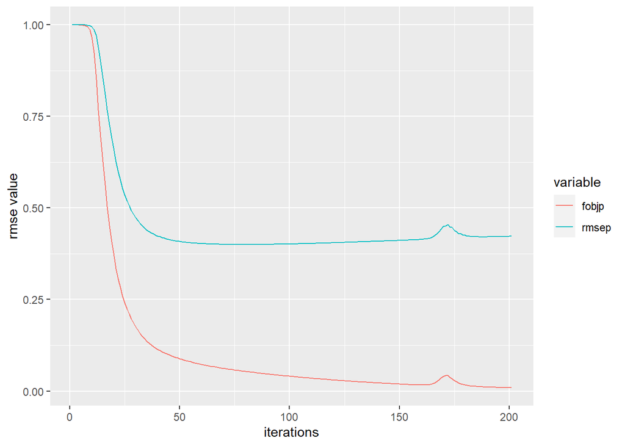

```r
path1 <- data.frame(itr = 1:(N+1), fobj, fobjp = fobj/max(fobj), rmse = rmsej, rmsep = rmsej/max(rmsej))
path1gg <- melt(path1[c("itr", "fobjp", "rmsep")], id.vars = "itr")
ggplot(path1gg, aes(itr, value, color = variable)) + geom_line()+labs(x = "iterations", y = "rmse value")
```

```r
dimnames(pred) <- list(user = rownames(ui_train), game = colnames(ui_train))

# printing final iteration
tail(path1, 1)
```

```
##     itr     fobj       fobjp     rmse     rmsep
## 201 201 3279.008 0.009087652 1.369454 0.4225904
```

A large improvement on the basic SVD approach. The output shows the objective function converged to 0 on the training data, while the error in the test set essentially halved. Interestingly after the 75th iteration the accuracy in the test set decreased. This could be improved by using more leading components, the trade off being computation time. We can stop after 75 to 100 iterations for this data. It is the prediction of the unobserved which is the goal for test data.

Using the predicted user-item matrix, we will look at the distribution of hours and apply an EM algoritm to find a reasonable 1-5 star rating

```
## WARNING! NOT CONVERGENT!
## number of iterations= 1000
##  lambda:  0.124213 0.2746307 0.500309 0.100609 0.0002383166
##  mean  :  0.4732782 1.327967 3.047156 4.393495 9.686336
##  sigma :  0.1720453 0.484695 0.9869391 1.300674 0.144994
```

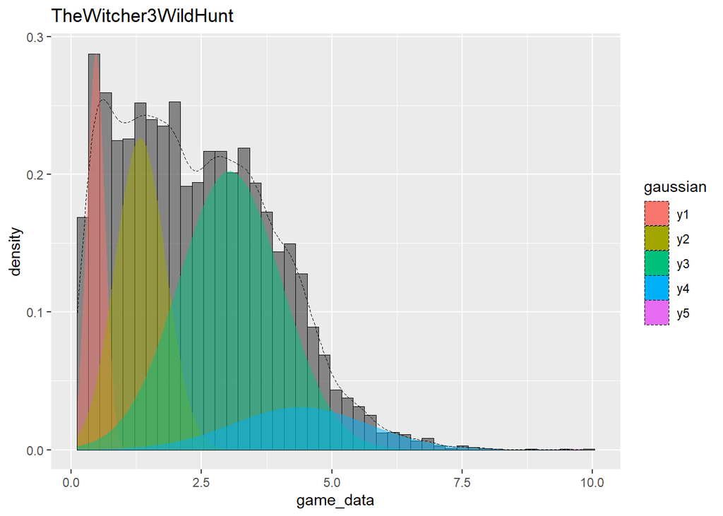

```r
# create a rating based on time played
# should consolodate this with the other one
game_hrs_density_p <- function(pred, GAME = NULL, nclass, print_vals = TRUE){

  if(is.null(GAME)){
    GAME <- sample(colnames(pred), 1)
  }

  # subsetting data
  game_data <- subset(pred[,GAME], pred[,GAME] > 0)

  # em algorithm
  mu.init <- seq(min(game_data), max(game_data), length = nclass)
  EM <- normalmixEM(game_data, mu = mu.init, sigma=rep(1, nclass), fast = TRUE)

  # print results
  if(print_vals){
    cat(" lambda: ", EM$lambda, "\n mean  : ", EM$mu, "\n sigma : ", EM$sigma, "\n")
  }

  # building data frame for plotting
  x <- seq(min(game_data), max(game_data), 0.01)
  dens <- data.frame(x = x)
  for(k in 1:nclass){
    dens[,paste0('y', k)] <- EM$lambda[k]*dnorm(x, EM$mu[k], EM$sigma[k])
  }

  dens <- melt(dens, 'x', variable.name = 'gaussian')
  game_plt <- ggplot(as.data.frame(game_data), aes(x = game_data)) +
    geom_histogram(aes(y = ..density..), bins = 45, colour = "black", alpha = 0.7, size = 0.1) +
    geom_area(data = dens, aes(x = x, y = value, fill = gaussian), alpha = 0.5, position = position_dodge()) +
    geom_density(linetype = 2, size = 0.1) +
    ggtitle(GAME)

  return(game_plt)
}
game_hrs_density_p(pred, "TheWitcher3WildHunt", 5)
```

It is not quite as appropriate this time as all the new predictions create a dense distribution. The 2-4 distributions look like they fit fairly well. The 5 on the other hand is rather flat and only picks up the very end of the tail.

### Now we use a percentile approach to recommend the top 10 games for a user for predicted user item matrix

```r
# List the top games for a user that they haven't purcahsed
pred_percentile <- apply(pred, 2, percent_rank)
top <- function(n, user = NULL){
  if(is.null(user)){
    user <- sample(rownames(pred_percentile), 1)
  }
  not_purchased <- (I-1)%%2
  top_games <- names(sort((pred_percentile*not_purchased)[user,], decreasing = TRUE))[1:n]
  cat("top", n, "recommended games for user", user, ":\n")
  for(k in 1:n){
    cat(k, ")", top_games[k], "\n")
  }
}
df1=top(10)
```

```
## top 10 recommended games for user u302054444 :
## 1 ) Unturned
## 2 ) Arma2OperationArrowhead
## 3 ) CounterStrikeSource
## 4 ) AlienSwarm
## 5 ) PlanetSide2
## 6 ) GarrysMod
## 7 ) H1Z1
## 8 ) CallofDutyBlackOpsMultiplayer
## 9 ) KillingFloor
## 10 ) NapoleonTotalWar
```